# 8: Representing Sequences of Words as Data

## Step 2: k-means Clustering

**Properties:**

- Minimises within cluster sum of squares.
- Clusters represented by centroid.

**Algorithm:**

1. Randomly initialise k centroids.
2. Assign each observation to the cluster with the nearest centroid.
3. Calculate new centroids for each cluster.
4. Repeat 2-3 until convergence.

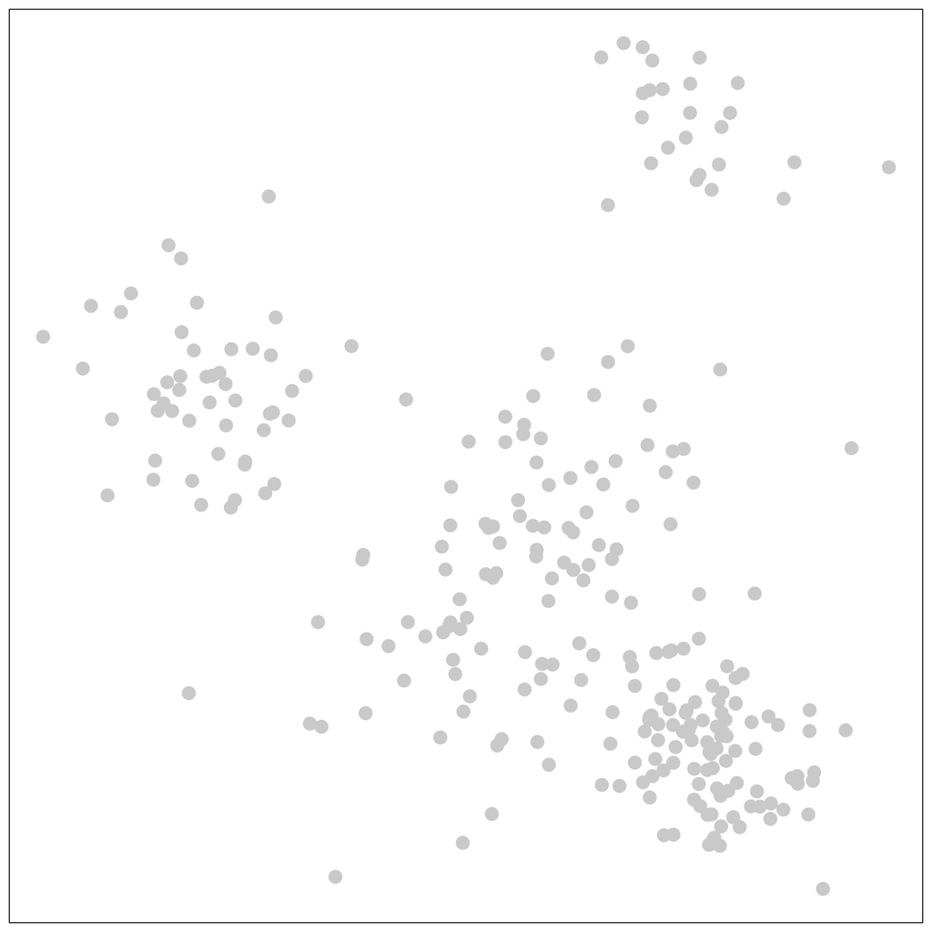

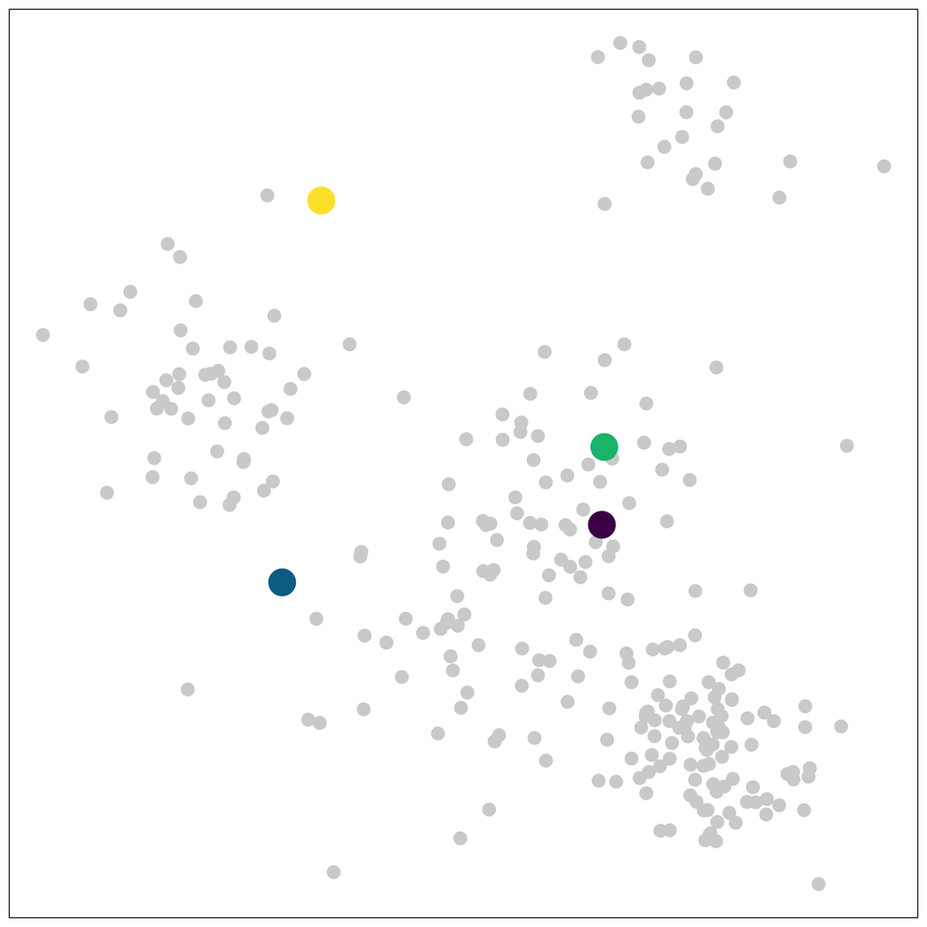

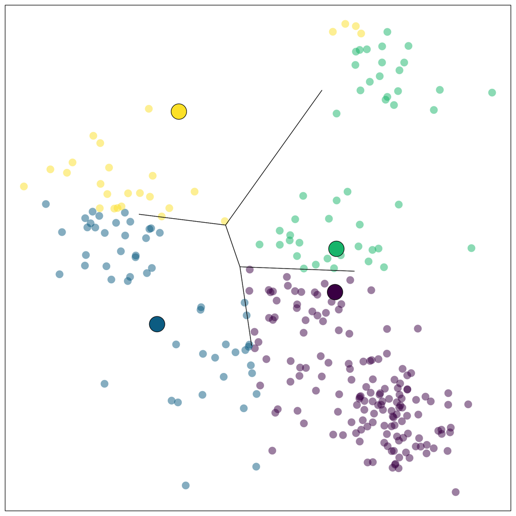

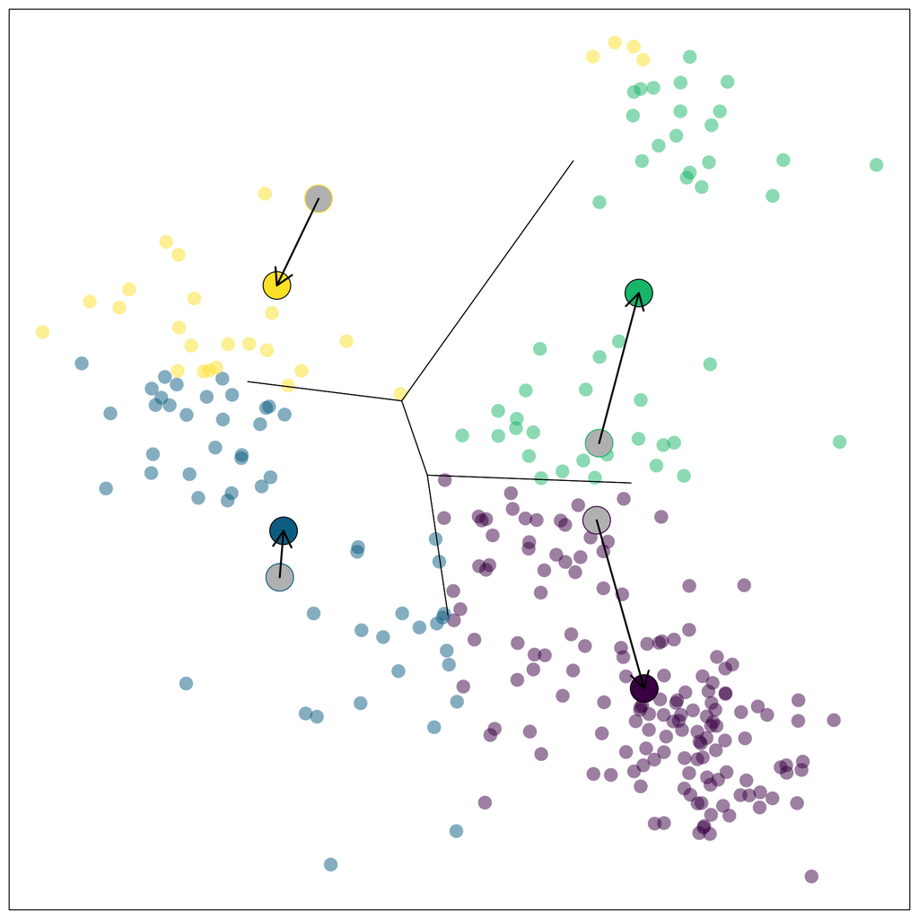

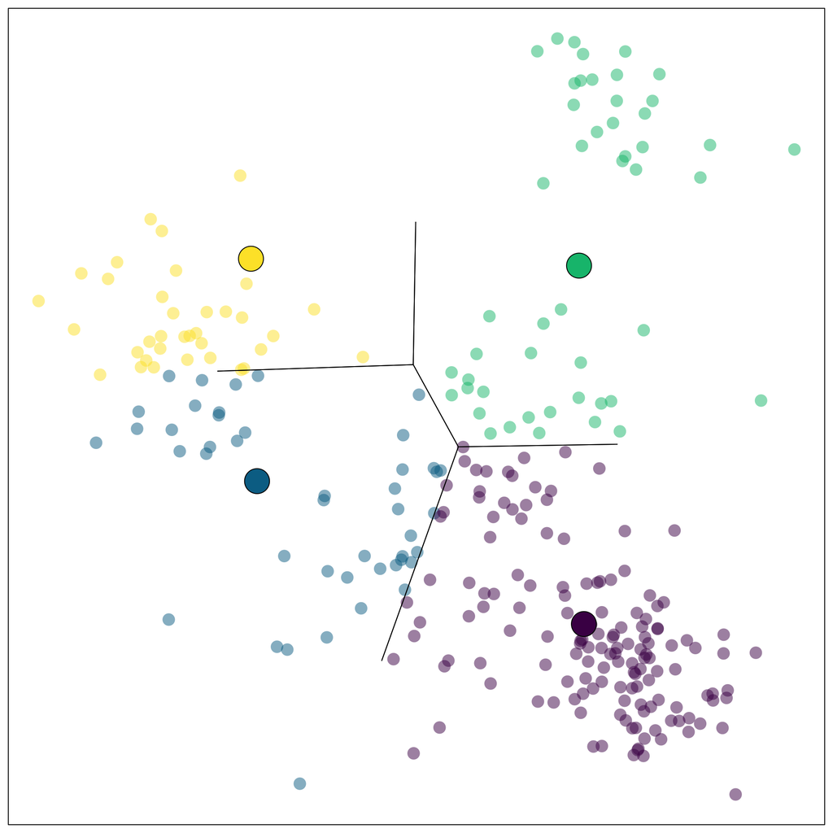

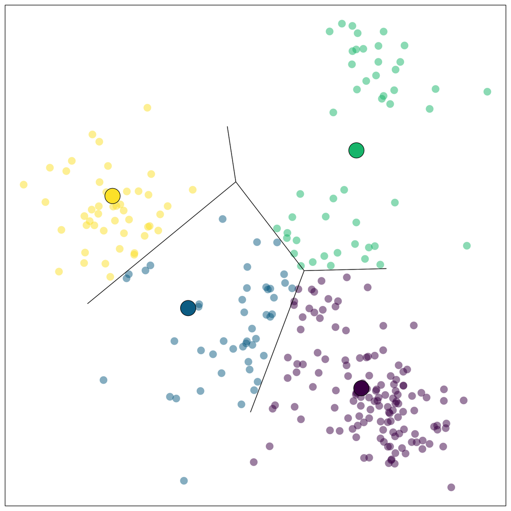

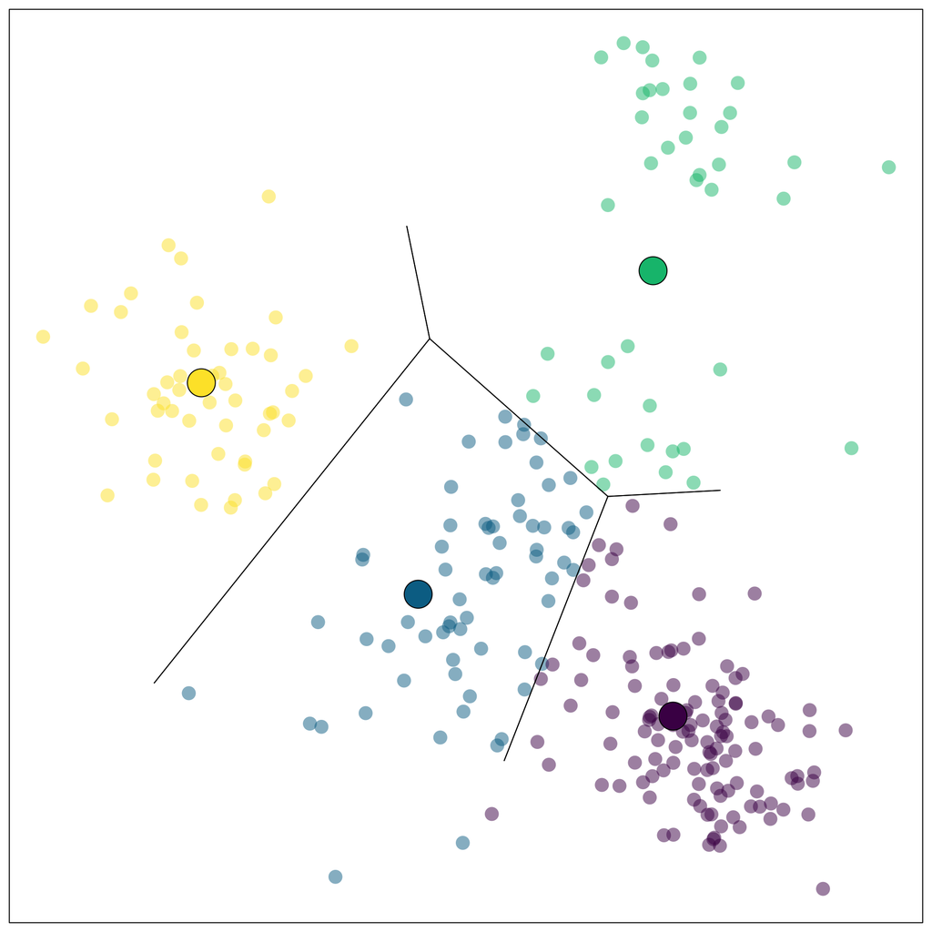

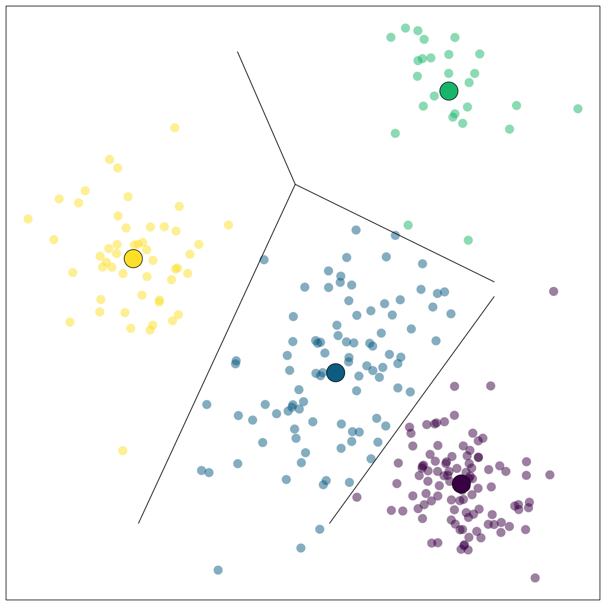

## Step 3: Label clusters

Within each cluster:

1. Calculate distance of each tweet from its centroid
2. Select the $m$ nearest as ‘representative examples’

Example cluster:

| Label: Fracking causes methane leaks |
| --- |
| Fracking leaks methane into atmosphere, which is 80x more harmful to climate than CO2 - remind me why GOVUK wants to exploit more FFs? |
| methane is a potent greenhouse gas related to fracking, yet rarely gets a mention. Thanks to James Hansen for this timely intervention: |
| Fracking's Methane Leakage To Be Focus of Many Studies This Year |
| Methane leakage isn't as bad as previously thought in the US's big fracking areas |
| DeSmogBlog US: "Methane Leaks Wipe Out Any Climate Benefit Of Fracking, Satellite Observations Confirm" |

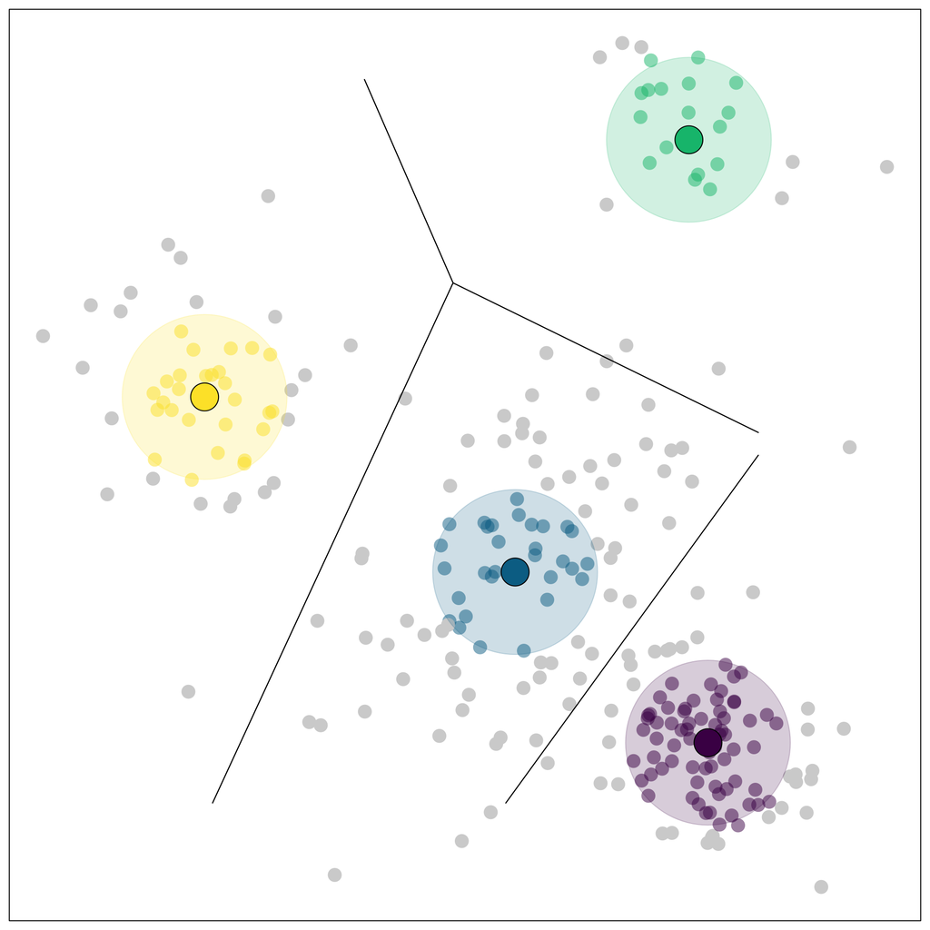

## Example claims

| Claims 1-10 |
| --- |
| Oppose shale/fracking |
| Protect UK wildlife |
| Support sustainable fishing |
| Support rapid carbon emissions cuts |
| Climate change has devastating effects |
| Oppose airport expansion |
| Support transition to renewables |
| Tackling climate change makes economic sense |
| Support green growth |
| Oppose new oil and gas |

| Claims 11-20 |
| --- |
| Protect the Amazon |
| Palm oil causes deforestation |
| Investments in renewables make economic sense |
| Oppose trade deals that reduce environmental standards |
| Promote biodiversity |
| Pesticides harm bees |
| Support sustainable/organic farming |
| Renewables are the future |
| Oppose disposable coffee cups |
| Demand action on air pollution |

| Claims 21-30 |
| --- |
| Invest more in (green) public transport |
| Climate change linked to biodiversity loss |
| Protect our oceans |
| Coal less efficient than renewables |
| Protect endangered species |
| Oppose fossil fuel lobbying |
| Fracking causes earthquakes |
| Oppose nuclear weapons |
| Oppose fossil fuel company sponsorship / greenwashing |
| Air pollution harms health |

## Comparing protest groups

| Reclaim the power top claims |
| --- |
| Oppose shale/fracking |
| Oppose fossil fuel use |
| Fracking incompatible with climate goals |
| Public opposed to fracking |
| Fracking harms health and environment |
| Fracking does not make economic sense |
| Oppose 'dash for gas' |
| Fracking linked to methane leaks |
| Fracking causes earthquakes |
| Oppose fossil fuel lobbying |

| Greenpeace top claims |
| --- |
| Protect our oceans |
| Plastic pollution harms oceans |
| Protect marine life |
| Soy production harms environment |
| Support bottle deposit scheme |
| Eat less meat |
| Oppose disposable coffee cups |
| Demand action on plastics |
| Protect the Amazon |
| Protect arctic/antarctic |

| XR top claims |
| --- |
| Time is running out for climate action |
| Demand climate action from government |
| Climate change has devastating effects |
| Save the planet |
| We are heading for extinction |
| Address climate change for childrens' sake |
| Oppose unsustainable fashion |
| Promote biodiversity |
| Climate change hits poorest hardest |
| Support net zero |

## Alternative clustering algorithms

- K-means is designed for *spherical* clusters. Struggles with other shapes.
- Alternative: **DBSCAN** (Density Based Spacial Clustering of Applications with Noise)
1. Distinguish between *core* and *non-core* observations based on their proximity to neighbours.
2. Combine *core* observations that are near to each other.
3. Assign *non-core* observations to nearest cluster if within $\epsilon$ else remove as outlier.

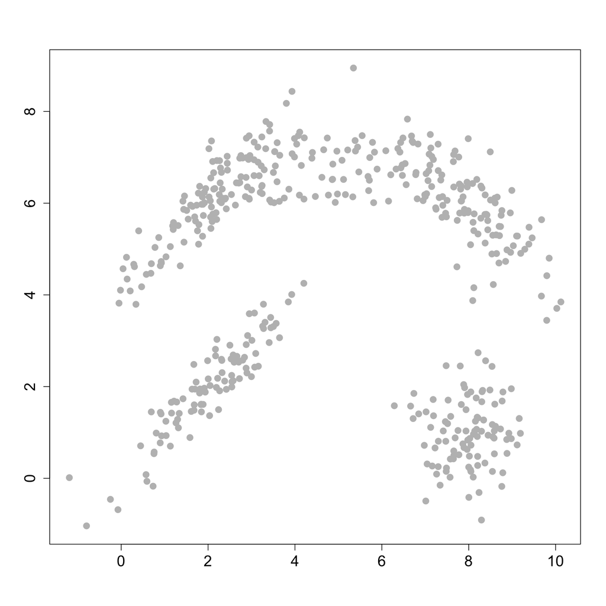

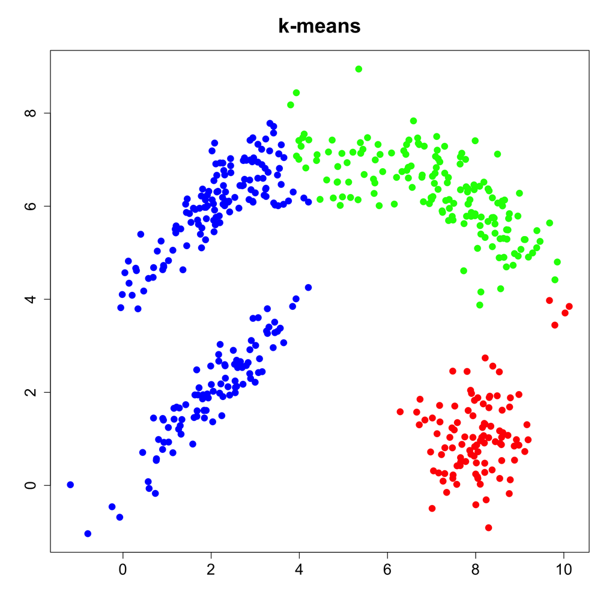

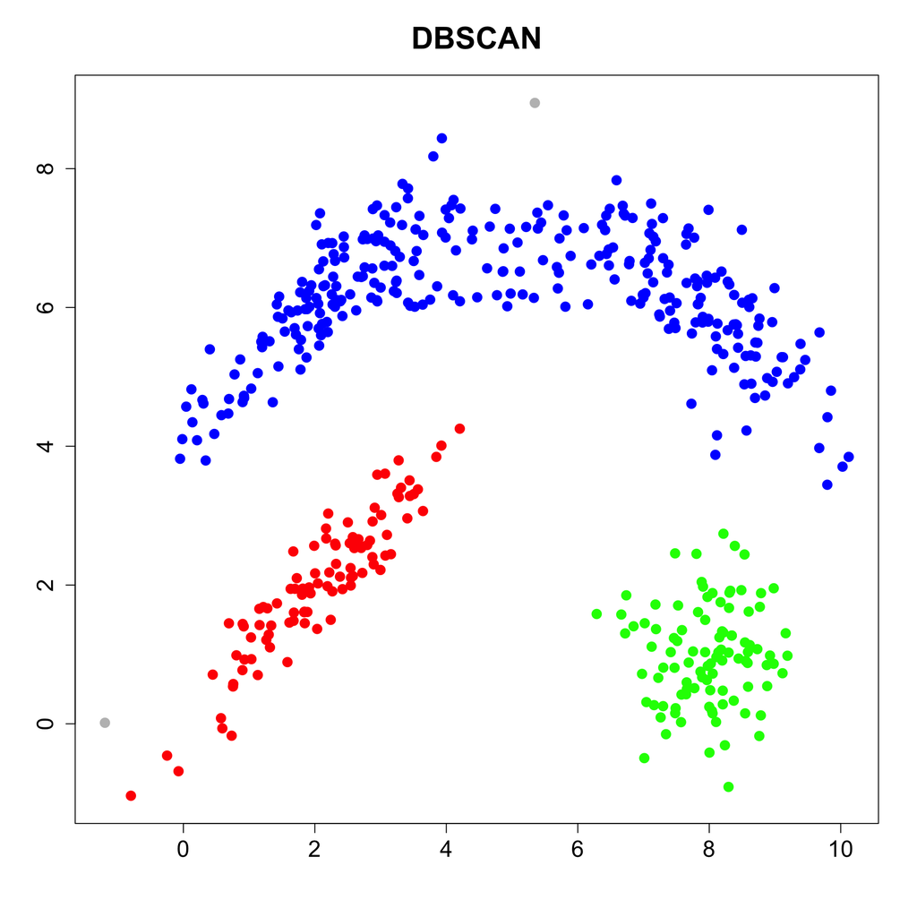

## Alternative labelling strategies

1. Manual inspection
2. Classed-based tf-idf
- Identify keywords associated with each cluster using:
- $||tf_{x,c}||+log(1+\frac{A}{f_x})$
- $tf_{x,c}$ = term frequency of word $x$ in class $c$
- $A$ = avg. num. words per class
- $f_x$ = freq. word x in all classes
3. Generative language models
- Prompt with representative examples from cluster

## BERTopic

BERTopic is a unified pipeline (in Python) for topic modelling using vector representations of texts

[figure not shown]

# Application II: Information Retrieval

## Does the media repeat protest group’s claims?

Search media corpus for sentences with high cosine similarity to the recovered claims.

1. Use a two sentence sliding window to segment news articles
2. Encode each segment in the same embedding space
3. Measure the cosine similarity between each segment and each claim
4. Assign segment to claim if $\text{cos}(claim, segment) > \tau$

## Face Validity

**Ecocide is a crime**

| cos_sim | statement |
| --- | --- |
| 0.82 | If widespread or systematic destruction of the environment ("ecocide") is listed as a crime against humanity, the international community would have a responsibility to prevent and punish that activit… |
| 0.82 | A global campaign to make "ecocide" a crime under international law is to be launched tomorrow in an attempt to outlaw the worst kinds of environmental destruction. A grassroots movement called End Ec… |
| 0.79 | A grassroots movement called End Ecocide on Earth is seeking to have the wholesale destruction of ecosystems ranked alongside offences such as genocide and war crimes. The International Criminal Court… |

**Fracking causes earthquakes**

| cos_sim | statement |
| --- | --- |
| 0.9 | "Within a day of Cuadrilla restarting fracking in Lancashire, there has already been another earthquake which means they've had to down tools," said Friends of the Earth campaigner Tony Bosworth. "It … |
| 0.9 | Page 2 2 The government has rejected an energy company's request to relax rules on earthquakes caused by fracking, despite claims that the limits could prevent it testing Britain's shale gas potential… |
| 0.9 | Cuadrilla caused what is described as a "micro-seismic event" measuring 1.1 on the Richter scale at Preston New Road in Lancashire yesterday, the strongest of 27 tremors since it resumed fracking two … |

**Support net zero**

| cos_sim | statement |
| --- | --- |
| 0.88 | "In the midst of a climate emergency, people across the UK are sending a clear message to the government that we need further and faster action to protect our environment and safeguard our planet for … |
| 0.87 | The Government's pledge to meet a net-zero target by 2050 is not a moment too soon. It must be commended for this bold commitment, echoing how the Climate Change Act gave the UK a world-leading role i… |
| 0.87 | Reaching net zero by 2050 is an ambitious target, but it is crucial that we achieve it to ensure we protect our planet for future generations." The Government said it would retain the ability to use i… |

## Validation

**How well does cosine similarity capture agreement?**

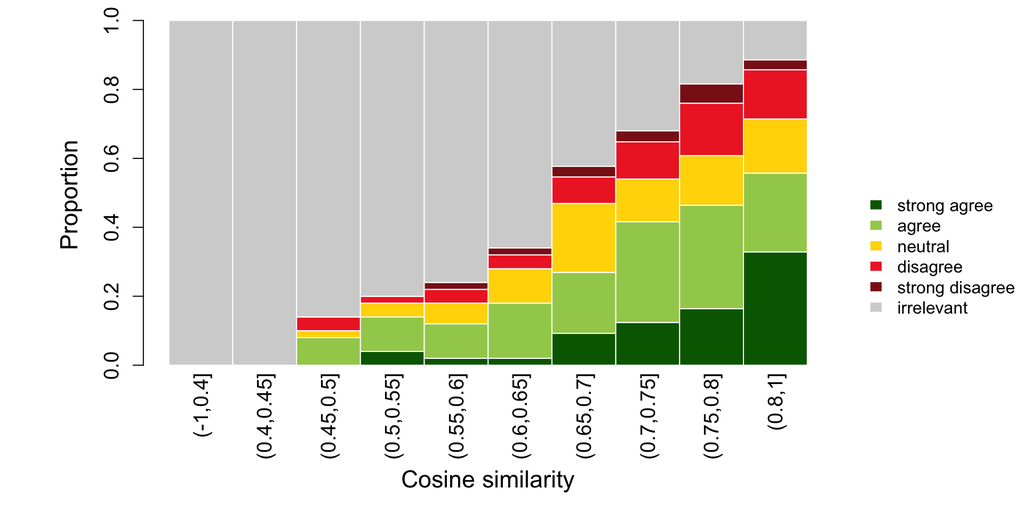

## Does the media repeat protest group’s claims?

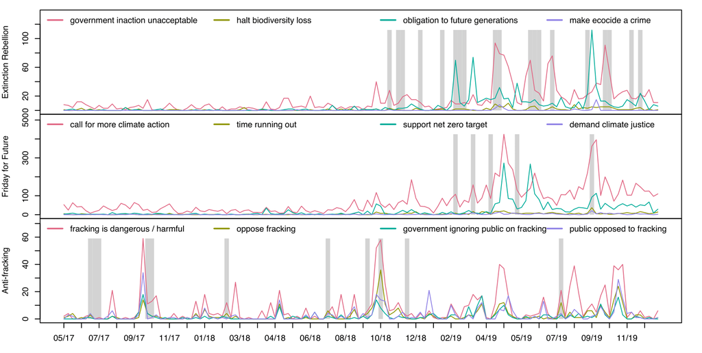

# Summary

## Recap

Moved beyond bag-of-words in three ways:

1. Subword tokenisation
2. Contextual embeddings
3. Sentence-BERT embeddings

Applications for:

1. Clustering
2. Information retrieval

## Next week

1. What is happening under the hood of BERT and other neural language models?
2. How can we use neural langauge models directly for more precise classification?

[figure not shown]

PUBL0099